# Baseline

### Задача

Прогнозирование показателей работы скважин является одной из наиболее востребованных задач в нефтегазовой отрасли. Несмотря на то, что данный вопрос исследован достаточно широко и известно много предметных методов математического моделирования, решающих данную задачу с большим или меньшим успехом, тем не менее такие методы обычно построены исходя из специфики геолого-технических характеристик месторождения и отдельных скважин. Очевидно, что при использовании таких методов моделирования на объектах с другими геолого-техническими характеристиками возникает необходимость их доработки или разработки новых способов эффективного прогнозирования показателей работы скважин. Поэтому очень актуальной задачей является быстрое и качественное построение прогностических моделей для показателей скважин с помощью методов машинного обучения.

Участниккам предлагается решить задачу прогнозирования основного показателя работы скважин (целевая переменная: `Дебит нефти`) с заблаговременностью 90 дней (вперед) для месторождения с 106 скважинами.

### Данные для обучения

По сути, тренировочные данные представляют собой геолого-технические показатели работы скважин, отнесенные к номеру скважины (`Номер скважины`), ее координатам (`x`, `y`) и даты (`datetime`) измерения показателей. Показатели скважины представлены следующими параметрами: `Дебит нефти` (целевая переменная), `Давление забойное`, `Объем жидкости`, `Объем нефти`, `Активная мощность (ТМ)`, `Время работы (ТМ)`, `Газовый фактор рабочий (ТМ)`, `Давление буферное`, `Давление забойное от Hд`, `Давление забойное от Pпр`, `Давление линейное (ТМ)`, `Давление на входе ЭЦН (ТМ)`, `Дебит газа (ТМ)`, `Дебит газа попутного`, `Дебит жидкости (ТМ)`, `Коэффициент мощности (ТМ)`.

Таким образом, таблица содержит столбцы (по порядку): `datetime`, `Номер скважины`, `Дебит нефти`, `Давление забойное`, `x`, `y`, `Объем жидкости`, `Объем нефти`, `Активная мощность (ТМ)`, `Время работы (ТМ)`, `Газовый фактор рабочий (ТМ)`, `Давление буферное`, `Давление забойное от Hд`, `Давление забойное от Pпр`, `Давление линейное (ТМ)`, `Давление на входе ЭЦН (ТМ)`, `Дебит газа (ТМ)`, `Дебит газа попутного`, `Дебит жидкости (ТМ)`, `Коэффициент мощности (ТМ)`.

Тренировочные данные предоставлены для периода с 1990-08-01 по 1992-04-11, содержат 620 суточных записей показателей скважин. Участникам предлагается сделать прогноз на 90 суток для диапазона дат с 1992-04-12 по 1992-07-10.

Данные для обучения модели расположены в папке data. Представляют собой файл train.csv.

Характеристики выборки:

- Размер train таблицы 67136 строк на 20 столбцов
- Количество уникальных скважин в train таблице 106

Пространственное расположение скважин по координатам `x` и `y` показано на рисунке ниже:

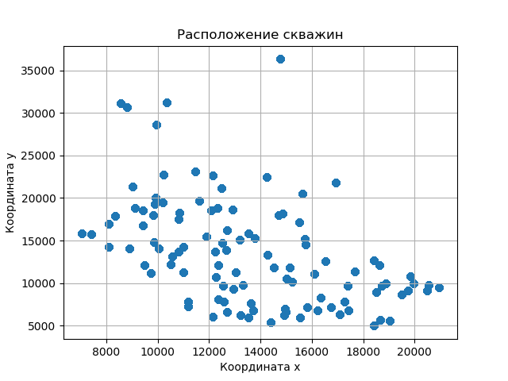

### Метрика для оценки ошибки модели

[Root Mean Square Error (RMSE)](https://scikit-learn.org/stable/modules/generated/sklearn.metrics.mean_squared_error.html)

Ошибка прогноза будет оцениваться на тестовой выборке, равной одному горизонту прогнозирования. Финальная метрика получается усреднением по всем скважинам.

### Формат загрузки данных

Пример генерируемой таблицы:

[output not shown]

**Файл необходимо сохранять в кодировке UTF-8!**

### Дополнительная информация

Стоит заметить, что приведенный пример решения задачи при помощи фреймворка FEDOT не является единственным. Участники могут как совершенствовать текущее решение, так и придумывать и пробовать собственные подходы.

Обратите внимание, что прогноз следует формировать в будущее. На прогнозируемые временные метки не будет доступно никакой дополнительной информации, кроме той, что уже выдана участникам в train.csv файле.